# R Graphics

Thomas Girke (thomas.girke@ucr.edu)

Last update: 04 July, 2016

# Contents

Note: the most recent version of this tutorial can be found [here](https://htmlpreview.github.io/?https://github.com/tgirke/GEN242/blob/master/vignettes/15_Rgraphics/Rgraphics.html) and a slide show [here](https://drive.google.com/file/d/0B-lLYVUOliJFUmFVa0N3Y0kxOVE/view?usp=sharing).

# 1 Overview

## 1.1 Graphics in R

- Powerful environment for visualizing scientific data
- Integrated graphics and statistics infrastructure
- Publication quality graphics
- Fully programmable
- Highly reproducible
- Full [LaTeX](http://www.latex-project.org/), [Sweave](http://www.stat.auckland.ac.nz/~dscott/782/Sweave-manual-20060104.pdf), [knitr](http://yihui.name/knitr/) and [R Markdown](http://rmarkdown.rstudio.com/) support. support
- Vast number of R packages with graphics utilities

## 1.2 Documentation on Graphics in R

- General
  - [Graphics Task Page](http://cran.r-project.org/web/views/Graphics.html)
  - [R Graph Gallery](http://www.r-graph-gallery.com/)
  - [R Graphical Manual](http://bm2.genes.nig.ac.jp/RGM2/index.php)
  - [Paul Murrell’s book R (Grid) Graphics](http://www.stat.auckland.ac.nz/~paul/RGraphics/rgraphics.html)
- Interactive graphics
  - [`rggobi` (GGobi)](http://www.ggobi.org/)
  - [`iplots`](http://www.iplots.org/)
  - [Open GL (`rgl`)](http://rgl.neoscientists.org/gallery.shtml)

## 1.3 Graphics Environments

- Viewing and savings graphics in R
  - On-screen graphics
  - postscript, pdf, svg
  - jpeg/png/wmf/tiff/…
- Four major graphics environments
  - Low-level infrastructure
    - R Base Graphics (low- and high-level)
    - `grid`: [Manual](http://www.stat.auckland.ac.nz/~paul/grid/grid.html), [Book](http://www.stat.auckland.ac.nz/~paul/RGraphics/rgraphics.html)
  - High-level infrastructure
    - `lattice`: [Manual](http://lmdvr.r-forge.r-project.org), [Intro](http://www.his.sunderland.ac.uk/~cs0her/Statistics/UsingLatticeGraphicsInR.htm), [Book](http://www.amazon.com/Lattice-Multivariate-Data-Visualization-Use/dp/0387759689)
    - `ggplot2`: [Manual](http://docs.ggplot2.org/current/), [Intro](http://www.ling.upenn.edu/~joseff/rstudy/summer2010_ggplot2_intro.html), [Book](http://had.co.nz/ggplot2/book/)

# 2 Base Graphics

## 2.1 Overview

- Important high-level plotting functions
  - `plot`: generic x-y plotting
  - `barplot`: bar plots
  - `boxplot`: box-and-whisker plot
  - `hist`: histograms
  - `pie`: pie charts
  - `dotchart`: cleveland dot plots
  - `image, heatmap, contour, persp`: functions to generate image-like plots
  - `qqnorm, qqline, qqplot`: distribution comparison plots
  - `pairs, coplot`: display of multivariant data
- Help on these functions
  - `?myfct`
  - `?plot`
  - `?par`

## 2.2 Preferred Input Data Objects

- Matrices and data frames
- Vectors
- Named vectors

## 2.3 Scatter Plots

### 2.3.1 Basic scatter plots

Sample data set for subsequent plots

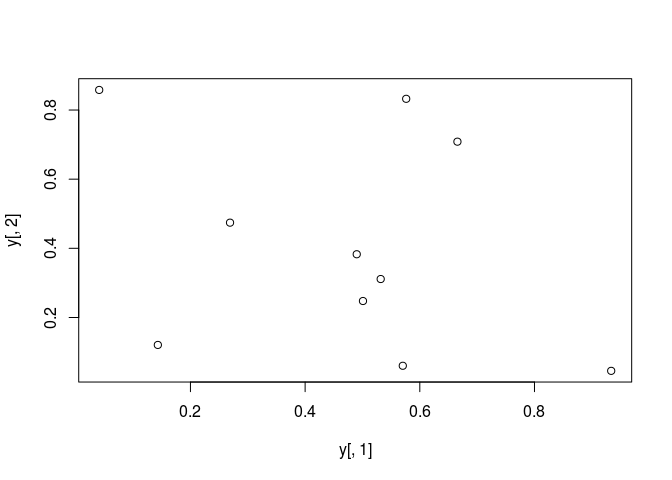

```r
set.seed(1410)
y <- matrix(runif(30), ncol=3, dimnames=list(letters[1:10], LETTERS[1:3]))
plot(y[,1], y[,2])
```

### 2.3.2 All pairs

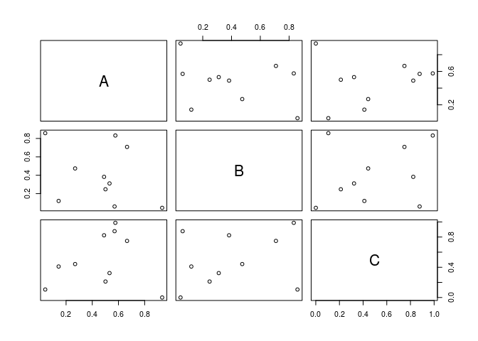

```r
pairs(y)
```

### 2.3.3 Plot labels

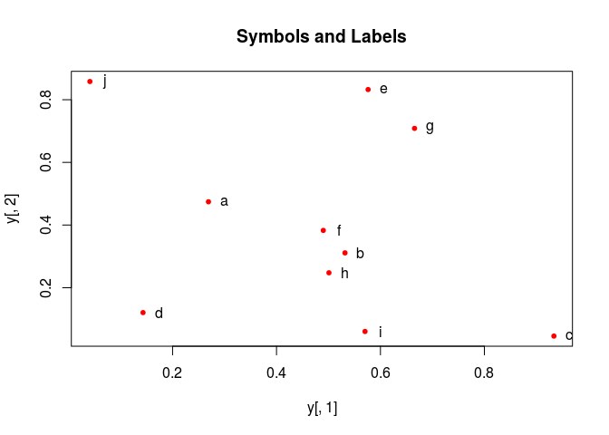

```r
plot(y[,1], y[,2], pch=20, col="red", main="Symbols and Labels")
text(y[,1]+0.03, y[,2], rownames(y))
```

### 2.3.4 More examples

Print instead of symbols the row names

```r
plot(y[,1], y[,2], type="n", main="Plot of Labels")
text(y[,1], y[,2], rownames(y))
```

Usage of important plotting parameters

```r
grid(5, 5, lwd = 2)
op <- par(mar=c(8,8,8,8), bg="lightblue")
plot(y[,1], y[,2], type="p", col="red", cex.lab=1.2, cex.axis=1.2,
     cex.main=1.2, cex.sub=1, lwd=4, pch=20, xlab="x label",
     ylab="y label", main="My Main", sub="My Sub")
par(op)
```

Important arguments} - `mar`: specifies the margin sizes around the plotting area in order: `c(bottom, left, top, right)` - `col`: color of symbols - `pch`: type of symbols, samples: `example(points)` - `lwd`: size of symbols - `cex.*`: control font sizes - For details see `?par`

Add a regression line to a plot

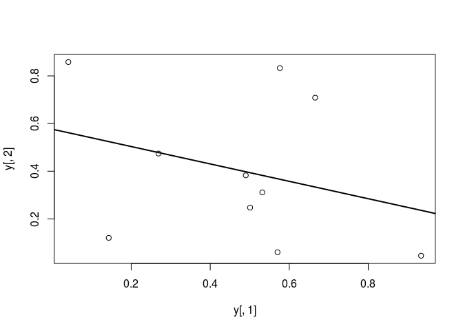

```r
plot(y[,1], y[,2])
myline <- lm(y[,2]~y[,1]); abline(myline, lwd=2)
```

```r
summary(myline)
```

```
##
## Call:
## lm(formula = y[, 2] ~ y[, 1])
##
## Residuals:
##      Min       1Q   Median       3Q      Max
## -0.40357 -0.17912 -0.04299  0.22147  0.46623
##
## Coefficients:
##             Estimate Std. Error t value Pr(>|t|)
## (Intercept)   0.5764     0.2110   2.732   0.0258 *
## y[, 1]       -0.3647     0.3959  -0.921   0.3839
## ---
## Signif. codes:  0 '***' 0.001 '**' 0.01 '*' 0.05 '.' 0.1 ' ' 1
##
## Residual standard error: 0.3095 on 8 degrees of freedom
## Multiple R-squared:  0.09589,    Adjusted R-squared:  -0.01712
## F-statistic: 0.8485 on 1 and 8 DF,  p-value: 0.3839
```

Same plot as above, but on log scale

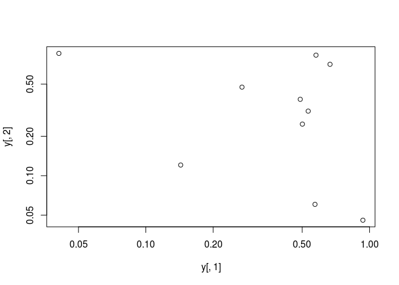

```r
plot(y[,1], y[,2], log="xy")
```

Add a mathematical expression to a plot

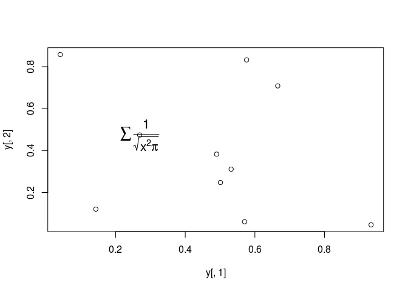

```r
plot(y[,1], y[,2]); text(y[1,1], y[1,2],
     expression(sum(frac(1,sqrt(x^2*pi)))), cex=1.3)
```

### 2.3.5 Exercise 1

- **Task 1**: Generate scatter plot for first two columns in `iris` data frame and color dots by its `Species` column.
- **Task 2**: Use the `xlim/ylim` arguments to set limits on the x- and y-axes so that all data points are restricted to the left bottom quadrant of the plot.

Structure of iris data set:

```r
class(iris)
```

```
## [1] "data.frame"
```

```r
iris[1:4,]
```

```
##   Sepal.Length Sepal.Width Petal.Length Petal.Width Species
## 1          5.1         3.5          1.4         0.2  setosa
## 2          4.9         3.0          1.4         0.2  setosa
## 3          4.7         3.2          1.3         0.2  setosa
## 4          4.6         3.1          1.5         0.2  setosa
```

```r
table(iris$Species)
```

```
##
##     setosa versicolor  virginica
##         50         50         50
```

## 2.4 Line Plots

### 2.4.1 Single Data Set

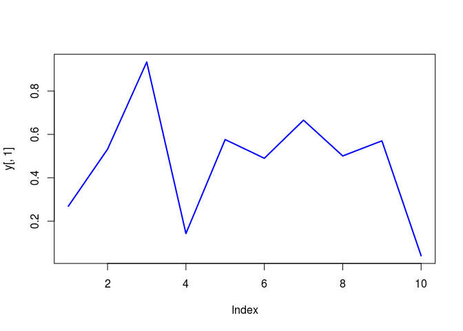

```r
plot(y[,1], type="l", lwd=2, col="blue")
```

### 2.4.2 Many Data Sets

Plots line graph for all columns in data frame `y`. The `split.screen` function is used in this example in a for loop to overlay several line graphs in the same plot.

```r
split.screen(c(1,1))
```

```
## [1] 1
```

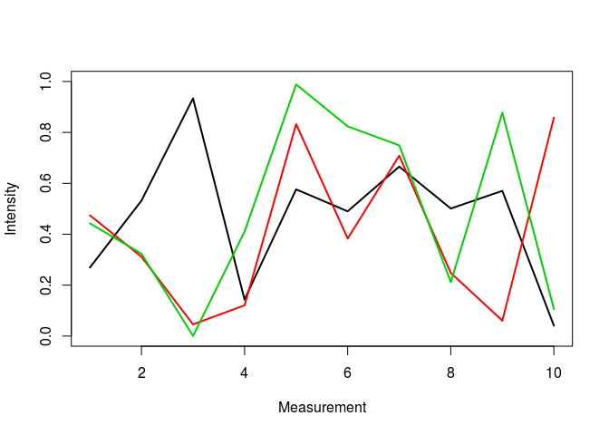

```r
plot(y[,1], ylim=c(0,1), xlab="Measurement", ylab="Intensity", type="l", lwd=2, col=1)
for(i in 2:length(y[1,])) {
    screen(1, new=FALSE)
    plot(y[,i], ylim=c(0,1), type="l", lwd=2, col=i, xaxt="n", yaxt="n", ylab="",
             xlab="", main="", bty="n")
}
```

```r
close.screen(all=TRUE)
```

## 2.5 Bar Plots

### 2.5.1 Basics

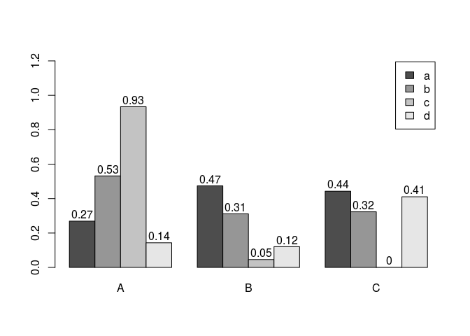

```r
barplot(y[1:4,], ylim=c(0, max(y[1:4,])+0.3), beside=TRUE,
        legend=letters[1:4])
text(labels=round(as.vector(as.matrix(y[1:4,])),2), x=seq(1.5, 13, by=1)
     +sort(rep(c(0,1,2), 4)), y=as.vector(as.matrix(y[1:4,]))+0.04)
```

### 2.5.2 Error bars

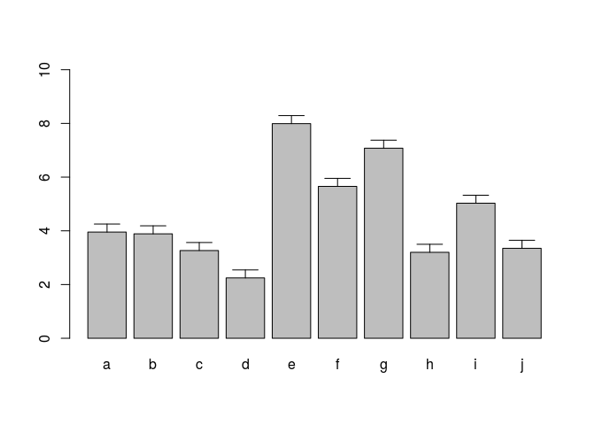

```r
bar <- barplot(m <- rowMeans(y) * 10, ylim=c(0, 10))
stdev <- sd(t(y))
arrows(bar, m, bar, m + stdev, length=0.15, angle = 90)
```

### 2.5.3 Mirrored bar plot

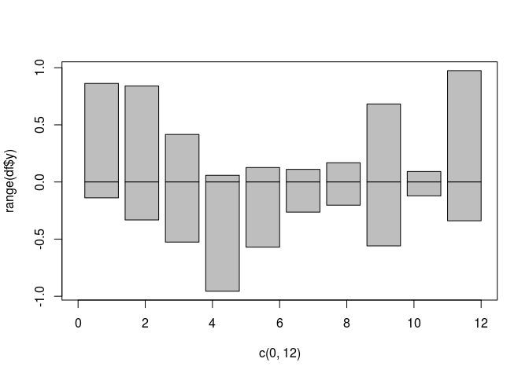

```r
df <- data.frame(group = rep(c("Above", "Below"), each=10), x = rep(1:10, 2), y = c(runif(10, 0, 1), runif(10, -1, 0)))
plot(c(0,12),range(df$y),type = "n")
barplot(height = df$y[df$group == "Above"], add = TRUE,axes = FALSE)
barplot(height = df$y[df$group == "Below"], add = TRUE,axes = FALSE)
```

## 2.6 Histograms

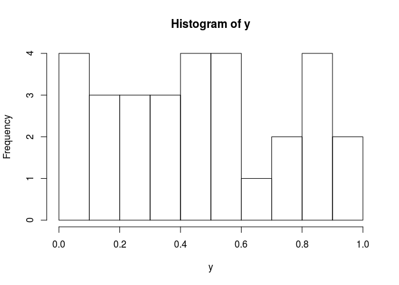

```r
hist(y, freq=TRUE, breaks=10)
```

## 2.7 Density Plots}

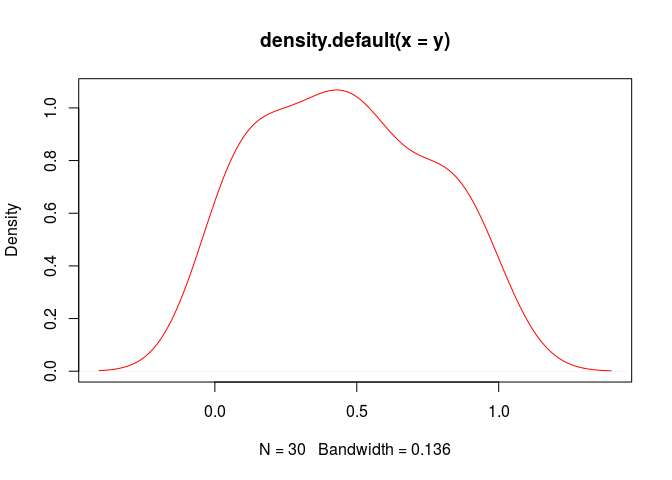

```r
plot(density(y), col="red")
```

## 2.8 Pie Charts

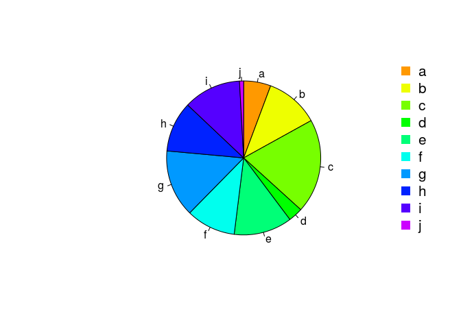

```r
pie(y[,1], col=rainbow(length(y[,1]), start=0.1, end=0.8), clockwise=TRUE)
legend("topright", legend=row.names(y), cex=1.3, bty="n", pch=15, pt.cex=1.8,
col=rainbow(length(y[,1]), start=0.1, end=0.8), ncol=1)
```

## 2.9 Color Selection Utilities

Default color palette and how to change it

```r
palette()
```

```
## [1] "black"   "red"     "green3"  "blue"    "cyan"    "magenta" "yellow"  "gray"
```

```r
palette(rainbow(5, start=0.1, end=0.2))
palette()
```

```
## [1] "#FF9900" "#FFBF00" "#FFE600" "#F2FF00" "#CCFF00"
```

```r
palette("default")
```

The `gray` function allows to select any type of gray shades by providing values from 0 to 1

```r
gray(seq(0.1, 1, by= 0.2))
```

```
## [1] "#1A1A1A" "#4D4D4D" "#808080" "#B3B3B3" "#E6E6E6"
```

Color gradients with `colorpanel` function from `gplots` library

```r
library(gplots)
colorpanel(5, "darkblue", "yellow", "white")
```

Much more on colors in R see Earl Glynn’s [color chart](http://research.stowers-institute.org/efg/R/Color/Chart/)

## 2.10 Arranging Several Plots on Single Page

With `par(mfrow=c(nrow,ncol))` one can define how several plots are arranged next to each other.

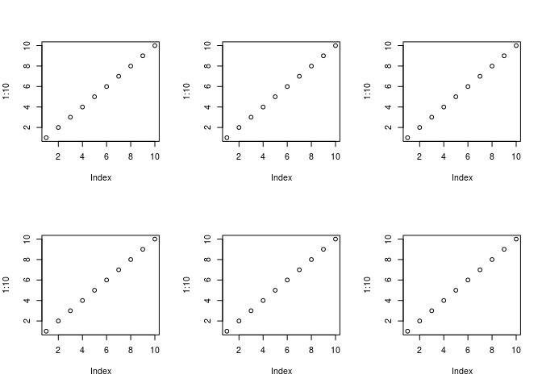

```r
par(mfrow=c(2,3)); for(i in 1:6) { plot(1:10) }
```

### 2.10.1 Arranging Plots with Variable Width

The `layout` function allows to divide the plotting device into variable numbers of rows and columns with the column-widths and the row-heights specified in the respective arguments.

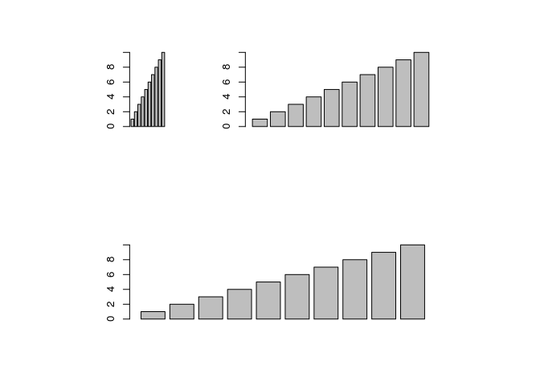

```r
nf <- layout(matrix(c(1,2,3,3), 2, 2, byrow=TRUE), c(3,7), c(5,5),
             respect=TRUE)
# layout.show(nf)
for(i in 1:3) { barplot(1:10) }
```

## 2.11 Saving Graphics to Files

After the `pdf()` command all graphs are redirected to file `test.pdf`. Works for all common formats similarly: jpeg, png, ps, tiff, …

```r
pdf("test.pdf"); plot(1:10, 1:10); dev.off()
```

Generates Scalable Vector Graphics (SVG) files that can be edited in vector graphics programs, such as InkScape.

```r
svg("test.svg"); plot(1:10, 1:10); dev.off()
```

### 2.11.1 Exercise 2

Bar plots

Structure of iris data set:

```r
class(iris)
```

```
## [1] "data.frame"
```

```r
iris[1:4,]
```

```
##   Sepal.Length Sepal.Width Petal.Length Petal.Width Species
## 1          5.1         3.5          1.4         0.2  setosa
## 2          4.9         3.0          1.4         0.2  setosa
## 3          4.7         3.2          1.3         0.2  setosa
## 4          4.6         3.1          1.5         0.2  setosa
```

```r
table(iris$Species)
```

```
##
##     setosa versicolor  virginica
##         50         50         50
```

# 3 Grid Graphics

- What is `grid`?
  - Low-level graphics system
  - Highly flexible and controllable system
  - Does not provide high-level functions
  - Intended as development environment for custom plotting functions
  - Pre-installed on new R distributions
- Documentation and Help
  - [Manual](http://www.stat.auckland.ac.nz/~paul/grid/grid.html)
  - [Book](http://www.stat.auckland.ac.nz/~paul/RGraphics/rgraphics.html)

# 4 lattice Graphics

- What is `lattice`?
  - High-level graphics system
  - Developed by Deepayan Sarkar
  - Implements Trellis graphics system from S-Plus
  - Simplifies high-level plotting tasks: arranging complex graphical features
  - Syntax similar to R’s base graphics
- Documentation and Help
  - [Manual](http://lmdvr.r-forge.r-project.org)
  - [Intro](http://www.his.sunderland.ac.uk/~cs0her/Statistics/UsingLatticeGraphicsInR.htm)
  - [Book](http://www.amazon.com/Lattice-Multivariate-Data-Visualization-Use/dp/0387759689)

Open a list of all functions available in the lattice package

```r
library(help=lattice)
```

Accessing and changing global parameters:

```r
?lattice.options
?trellis.device
```

## 4.1 Scatter Plot Sample

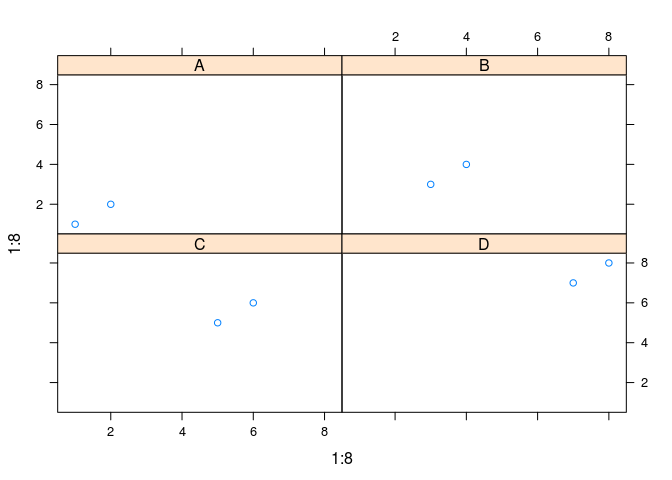

```r
library(lattice)
p1 <- xyplot(1:8 ~ 1:8 | rep(LETTERS[1:4], each=2), as.table=TRUE)
plot(p1)
```

## 4.2 Line Plot Sample

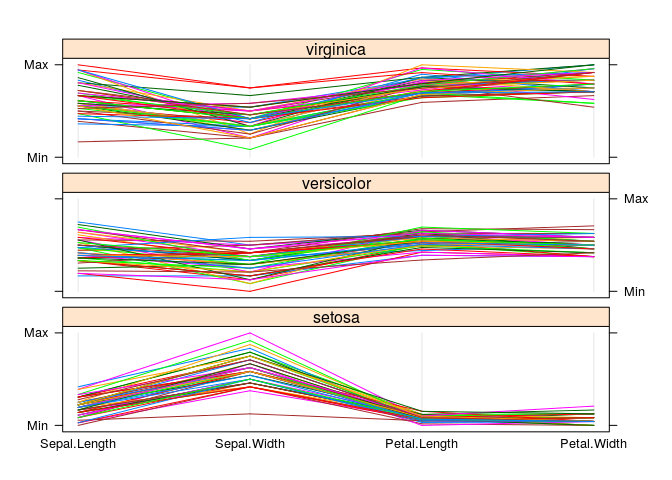

```r
library(lattice)
p2 <- parallelplot(~iris[1:4] | Species, iris, horizontal.axis = FALSE,
              layout = c(1, 3, 1))
plot(p2)
```

# 5 ggplot2 Graphics

- What is `ggplot2`?
  - High-level graphics system
  - Implements grammar of graphics from [Leland Wilkinson](http://www.amazon.com/Grammar-Graphics-Leland-Wilkinson/dp/0387987746)
  - Streamlines many graphics workflows for complex plots
  - Syntax centered around main `ggplot` function
  - Simpler `qplot` function provides many shortcuts
- Documentation and Help
  - [Manual](http://had.co.nz/ggplot2/)
  - [Intro](http://www.ling.upenn.edu/~joseff/rstudy/summer2010_ggplot2_intro.html)
  - [Book](http://had.co.nz/ggplot2/book/)
  - [Cookbook for R](http://www.cookbook-r.com/Graphs/)

## 5.1 `ggplot2` Usage

- `ggplot` function accepts two arguments
  - Data set to be plotted
  - Aesthetic mappings provided by `aes` function
- Additional parameters such as geometric objects (*e.g.* points, lines, bars) are passed on by appending them with `+` as separator.
- List of available `geom_*` functions see [here](http://docs.ggplot2.org/current/)
- Settings of plotting theme can be accessed with the command `theme_get()` and its settings can be changed with `theme()`.
- Preferred input data object
  - `qplot`: `data.frame` (support for `vector`, `matrix`, `...`)
  - `ggplot`: `data.frame`
- Packages with convenience utilities to create expected inputs
  - `plyr`
  - `reshape`

## 5.2 `qplot` Function

The syntax of `qplot` is similar as R’s basic `plot` function

- Arguments
  - `x`: x-coordinates (*e.g.* `col1`)
  - `y`: y-coordinates (*e.g.* `col2`)
  - `data`: data frame with corresponding column names
  - `xlim, ylim`: *e.g.* `xlim=c(0,10)`
  - `log`: *e.g.* `log="x"` or `log="xy"`
  - `main`: main title; see `?plotmath` for mathematical formula
  - `xlab, ylab`: labels for the x- and y-axes
  - `color`, `shape`, `size`
  - `...`: many arguments accepted by `plot` function

## 5.3 `qplot`: scatter plot basics

Create sample data

```r
library(ggplot2)
x <- sample(1:10, 10); y <- sample(1:10, 10); cat <- rep(c("A", "B"), 5)
```

Simple scatter plot

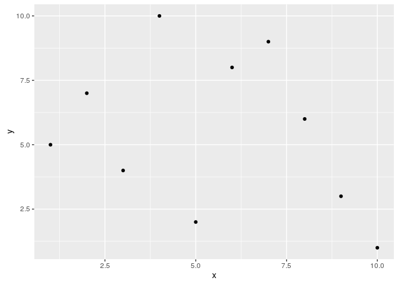

```r
qplot(x, y, geom="point")
```

Prints dots with different sizes and colors

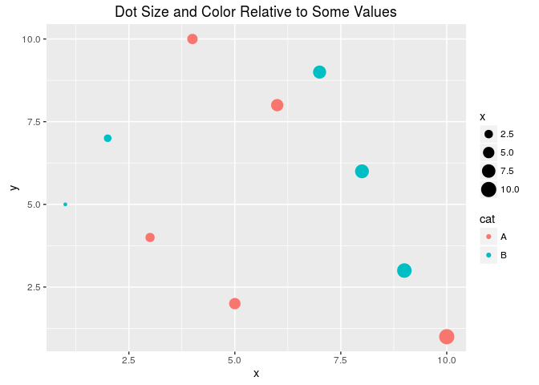

```r
qplot(x, y, geom="point", size=x, color=cat,
      main="Dot Size and Color Relative to Some Values")
```

Drops legend

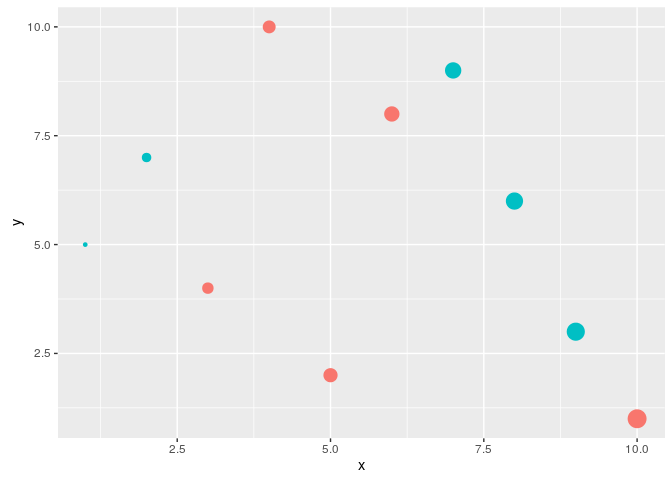

```r
qplot(x, y, geom="point", size=x, color=cat) +
      theme(legend.position = "none")
```

Plot different shapes

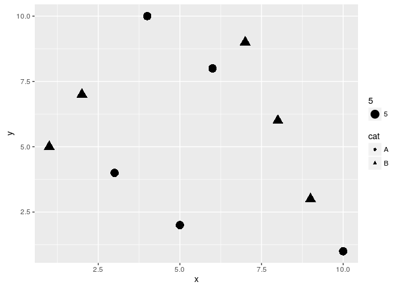

```r
qplot(x, y, geom="point", size=5, shape=cat)
```

### 5.3.1 Colored groups

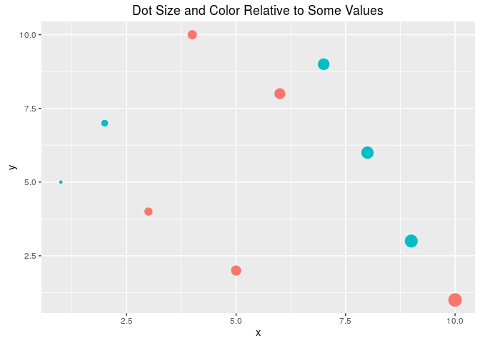

```r
p <- qplot(x, y, geom="point", size=x, color=cat,
            main="Dot Size and Color Relative to Some Values") +
     theme(legend.position = "none")
print(p)
```

### 5.3.2 Regression line

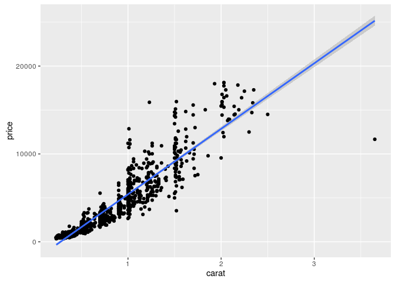

```r
set.seed(1410)
dsmall <- diamonds[sample(nrow(diamonds), 1000), ]
p <- qplot(carat, price, data = dsmall) +
           geom_smooth(method="lm")
print(p)
```

### 5.3.3 Local regression curve (loess)

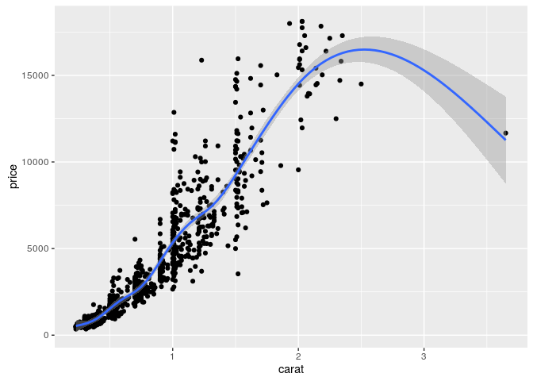

```r
p <- qplot(carat, price, data=dsmall, geom=c("point", "smooth"))
print(p) # Setting se=FALSE removes error shade
```

## 5.4 `ggplot` Function

- More important than `qplot` to access full functionality of `ggplot2`
- Main arguments
  - data set, usually a `data.frame`
  - aesthetic mappings provided by `aes` function
- General `ggplot` syntax
  - `ggplot(data, aes(...)) + geom() + ... + stat() + ...`
- Layer specifications
  - `geom(mapping, data, ..., geom, position)`
  - `stat(mapping, data, ..., stat, position)`
- Additional components
  - `scales`
  - `coordinates`
  - `facet`
- `aes()` mappings can be passed on to all components (`ggplot, geom`, etc.). Effects are global when passed on to `ggplot()` and local for other components.
  - `x, y`
  - `color`: grouping vector (factor)
  - `group`: grouping vector (factor)

### 5.4.1 Changing Plotting Themes in `ggplot`

- Theme settings can be accessed with `theme_get()`
- Their settings can be changed with `theme()`

Example how to change background color to white

```r
... + theme(panel.background=element_rect(fill = "white", colour = "black"))
```

### 5.4.2 Storing `ggplot` Specifications

Plots and layers can be stored in variables

```r
p <- ggplot(dsmall, aes(carat, price)) + geom_point()
p # or print(p)
```

Returns information about data and aesthetic mappings followed by each layer

```r
summary(p)
```

Print dots with different sizes and colors

```r
bestfit <- geom_smooth(methodw = "lm", se = F, color = alpha("steelblue", 0.5), size = 2)
p + bestfit # Plot with custom regression line
```

Syntax to pass on other data sets

```r
p %+% diamonds[sample(nrow(diamonds), 100),]
```

Saves plot stored in variable `p` to file

```r
ggsave(p, file="myplot.pdf")
```

## 5.5 `ggplot`: scatter plots

### 5.5.1 Basic example

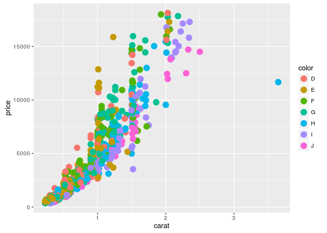

```r
p <- ggplot(dsmall, aes(carat, price, color=color)) +
            geom_point(size=4)
print(p)
```

### 5.5.2 Regression line

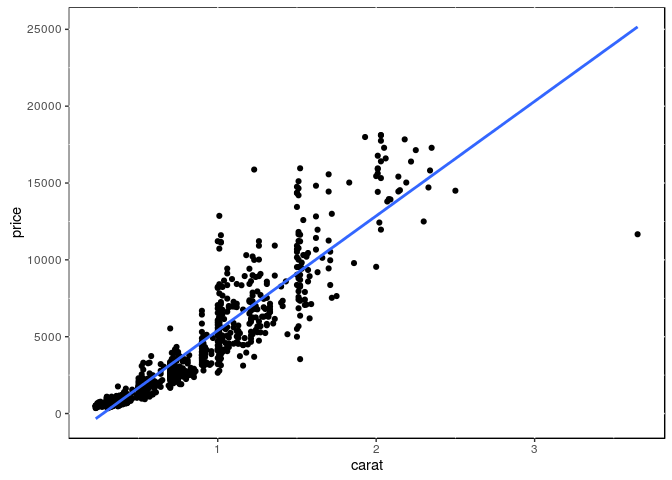

```r
p <- ggplot(dsmall, aes(carat, price)) + geom_point() +
            geom_smooth(method="lm", se=FALSE) +
            theme(panel.background=element_rect(fill = "white", colour = "black"))
print(p)
```

### 5.5.3 Several regression lines

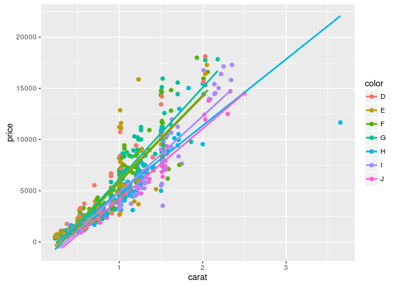

```r
p <- ggplot(dsmall, aes(carat, price, group=color)) +
            geom_point(aes(color=color), size=2) +
            geom_smooth(aes(color=color), method = "lm", se=FALSE)
print(p)
```

### 5.5.4 Local regression curve (loess)

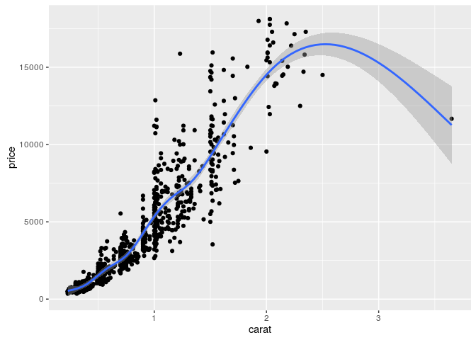

```r
p <- ggplot(dsmall, aes(carat, price)) + geom_point() + geom_smooth()
print(p) # Setting se=FALSE removes error shade
```

## 5.6 `ggplot`: line plot

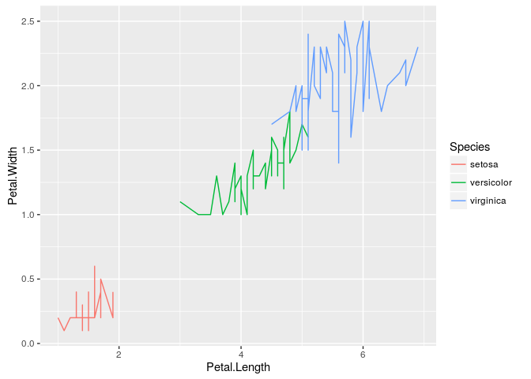

```r
p <- ggplot(iris, aes(Petal.Length, Petal.Width, group=Species,
            color=Species)) + geom_line()
print(p)
```

## 5.7 Faceting

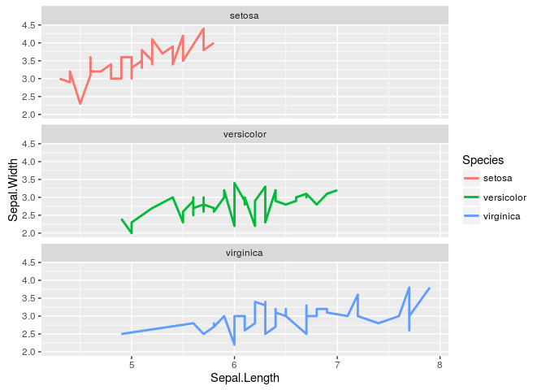

```r
p <- ggplot(iris, aes(Sepal.Length, Sepal.Width)) +
            geom_line(aes(color=Species), size=1) +
            facet_wrap(~Species, ncol=1)
print(p)
```

### 5.7.1 Exercise 3

Scatter plots with `ggplot2`

Structure of `iris` data set

```r
class(iris)
```

```
## [1] "data.frame"
```

```r
iris[1:4,]
```

```
##   Sepal.Length Sepal.Width Petal.Length Petal.Width Species
## 1          5.1         3.5          1.4         0.2  setosa
## 2          4.9         3.0          1.4         0.2  setosa
## 3          4.7         3.2          1.3         0.2  setosa
## 4          4.6         3.1          1.5         0.2  setosa
```

```r
table(iris$Species)
```

```
##
##     setosa versicolor  virginica
##         50         50         50
```

## 5.8 Bar plots

Sample Set: the following transforms the `iris` data set into a ggplot2-friendly format.

Calculate mean values for aggregates given by `Species` column in `iris` data set

```r
iris_mean <- aggregate(iris[,1:4], by=list(Species=iris$Species), FUN=mean)
```

Calculate standard deviations for aggregates given by `Species` column in `iris` data set

```r
iris_sd <- aggregate(iris[,1:4], by=list(Species=iris$Species), FUN=sd)
```

Reformat `iris_mean` with `melt`

```r
library(reshape2) # Defines melt function
df_mean <- melt(iris_mean, id.vars=c("Species"), variable.name = "Samples", value.name="Values")
```

Reformat `iris_sd` with `melt`

```r
df_sd <- melt(iris_sd, id.vars=c("Species"), variable.name = "Samples", value.name="Values")
```

Define standard deviation limits

```r
limits <- aes(ymax = df_mean[,"Values"] + df_sd[,"Values"], ymin=df_mean[,"Values"] - df_sd[,"Values"])
```

### 5.8.1 Verical orientation

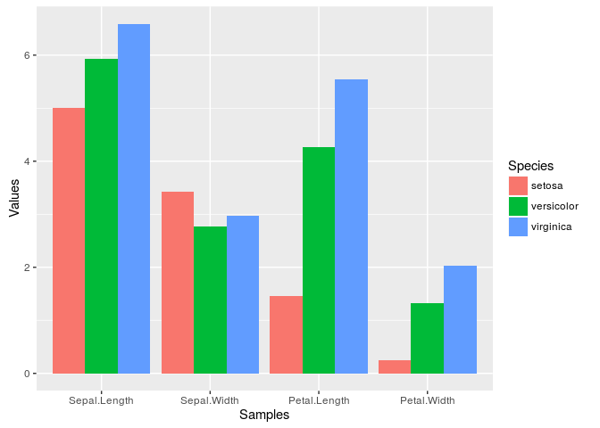

```r
p <- ggplot(df_mean, aes(Samples, Values, fill = Species)) +
        geom_bar(position="dodge", stat="identity")
print(p)
```